## Model assumptions

My data points are one measurement for each chromosome and individual, and for them I have information about crossover rate, number of cells, heterozygous inversions, number of different types of aneluploidies. Telocentric chromosomes should be discarded from the arm aberration measurements, since they were counted as whole chromosome aberrations.

The assumptions of the Ordinal Logistic Regression are as follow:

1. The dependent variable is ordered.
2. One or more of the independent variables are either continuous, categorical or ordinal.
3. No multi-collinearity.
4. Proportional odds.

I show the data distributions in the Figure @ref(fig:varDistribution).

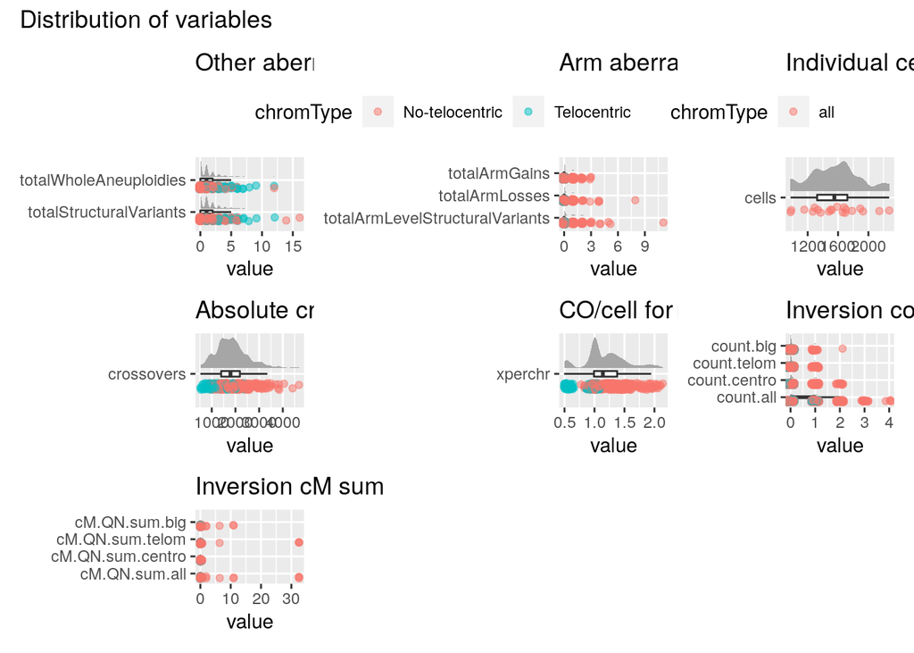

Raincloud plots for each variable.

From now on, no telocentric chroms

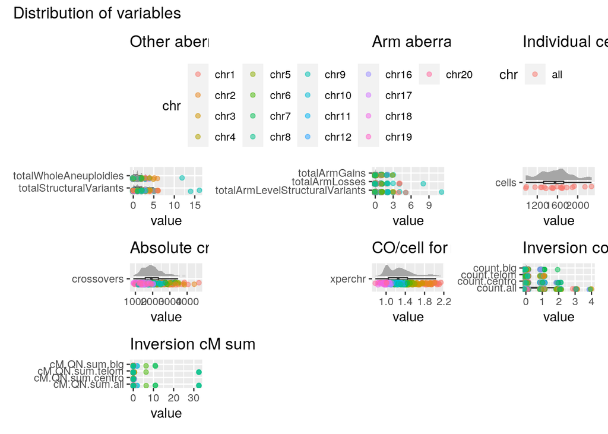

Raincloud plots for each variable.

Original category counts

| CountGroups | totalWholeAneuploidies | totalArmLosses | totalArmGains |
| --- | --- | --- | --- |
| 0 | 171 | 300 | 286 |
| 1 | 108 | 31 | 44 |
| 12 | 1 | NA | NA |
| 2 | 39 | 4 | 7 |
| 3 | 14 | 1 | 3 |
| 4 | 4 | 3 | NA |
| 5 | 2 | NA | NA |
| 6 | 1 | NA | NA |
| 8 | NA | 1 | NA |

New category counts

| CountGroups | totalWholeAneuploidiesCategory | totalArmLossesCategory | totalArmGainsCategory |
| --- | --- | --- | --- |
| 0 | 171 | 300 | 286 |
| 1 | 108 | 31 | 44 |
| 2 | 39 | 4 | 7 |
| 3+ | 22 | 5 | 3 |

With these groups, I visualize the relationships between dependent and independent variables in Figure @ref(fig:groupDifferences).

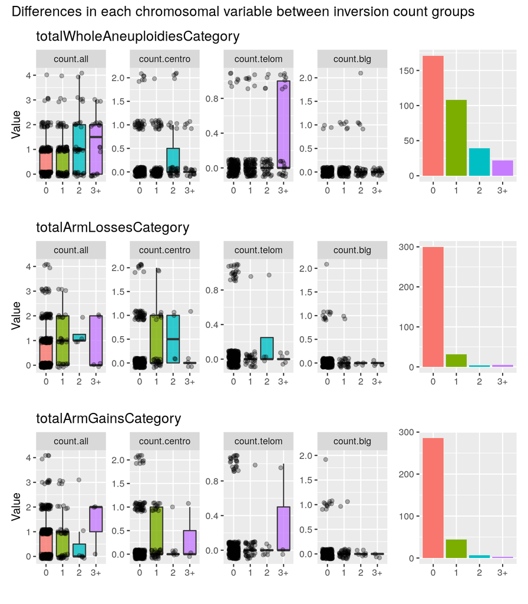

Boxplots for each dependent variable group and each independent variable quickly show candidates of having a strong effect. We can also see that there is missing data for some chromosome region types, because windows with 3+ inversions are scarce.

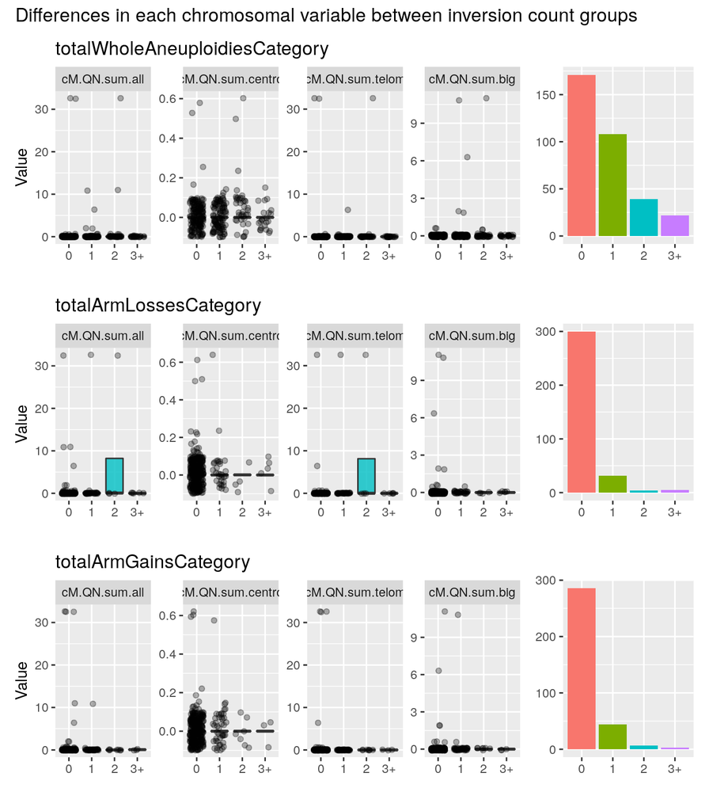

Boxplots for each dependent variable group and each independent variable quickly show candidates of having a strong effect. We can also see that there is missing data for some chromosome region types, because windows with 3+ inversions are scarce.

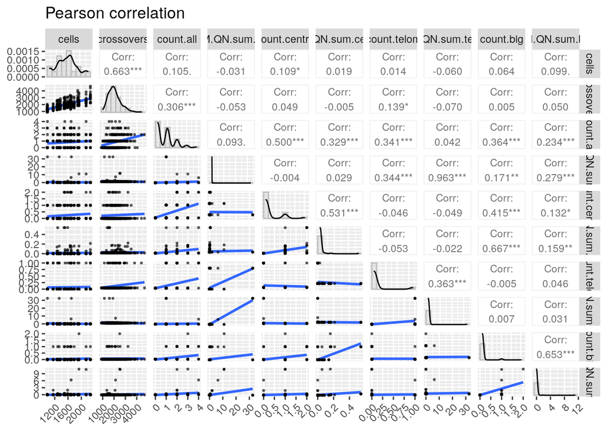

Correlation matrix of independent variables.

Variance Inflation Factor

|  | x |
| --- | --- |
| cells | 1.838675 |
| crossovers | 2.036542 |
| count.all | 1.154958 |
| cM.QN.sum.all | 1.017022 |

Variance Inflation Factor

|  | x |
| --- | --- |
| cells | 1.823457 |
| crossovers | 1.887041 |
| count.telom | 1.207075 |
| cM.QN.sum.telom | 1.173142 |

Variance Inflation Factor

|  | x |
| --- | --- |
| cells | 1.817499 |
| crossovers | 1.801033 |
| count.centro | 1.418274 |
| cM.QN.sum.centro | 1.401721 |

Variance Inflation Factor

|  | x |
| --- | --- |
| cells | 1.815864 |
| crossovers | 1.804669 |
| count.big | 1.746590 |
| cM.QN.sum.big | 1.753312 |

The proportional odds assumption will be tested for each model that we fit in the following analyses.

## Scaling of distributions

Standardized coefficients are useful in multiple scenarios,for example, to compare effects of predictors reported in different units. In out case it is necessary because the `polr` function depends on methods that require data scalation for them to be the reliable. The most straightforward way is using the Agresti method of standardization, applied with the `scale()` function, which adjusts the mean to 0 and the standard deviation to 1. Once the model is fitted, we can use the standard deviation of the original distribution to transform scaled coefficients to natural coefficients and viceversa.